# Testing New Compilation Method

Paddy O’Toole

2023-04-14

Here, we would like to test that the following have not been significantly changed by taking on kaskr’s suggestions on the choice of AD framework used by `TMB::compile` (TMBad vs the default of CppAD): 1. modelling results and 2. time to fit.

Of course, we would also like to have seen a decrease in the memory spike experienced while fitting!

## Prelims

```r
library(dplyr)
```

```r
library(ggplot2)
library(microbenchmark)
```

```r
# load shell and areas datasets for Lesotho
shell_dat_lso <- readr::read_csv("data/shell_data_lso.csv.gz")
areas <- sf::read_sf("data/areas.geojson")
```

```r
# Source functions & load mod
source("threemc_fit.R")
mod <- readLines("src/threemc.cpp")
```

## Fit Models

Compile our two models:

```r
# `framework` is passed to `TMB::compile`
mod_cppad <- tmb_compile_and_load(mod, framework = "CppAD")
mod_tmbad <- tmb_compile_and_load(mod, framework = "TMBad")
```

Fit our models with `threemc`.

```r
# fit model with CPPad
fit_cppad <-  memprof::with_monitor(threemc_fit(
  shell_dat_lso, areas, mod_cppad, silent = TRUE
))
# fit model with TMBad
fit_tmbad <-  memprof::with_monitor(threemc_fit(
  shell_dat_lso, areas, mod_tmbad, silent = TRUE
))
```

## 0: Memory used

Inspect the memory used by both AD frameworks with `memeprof`:

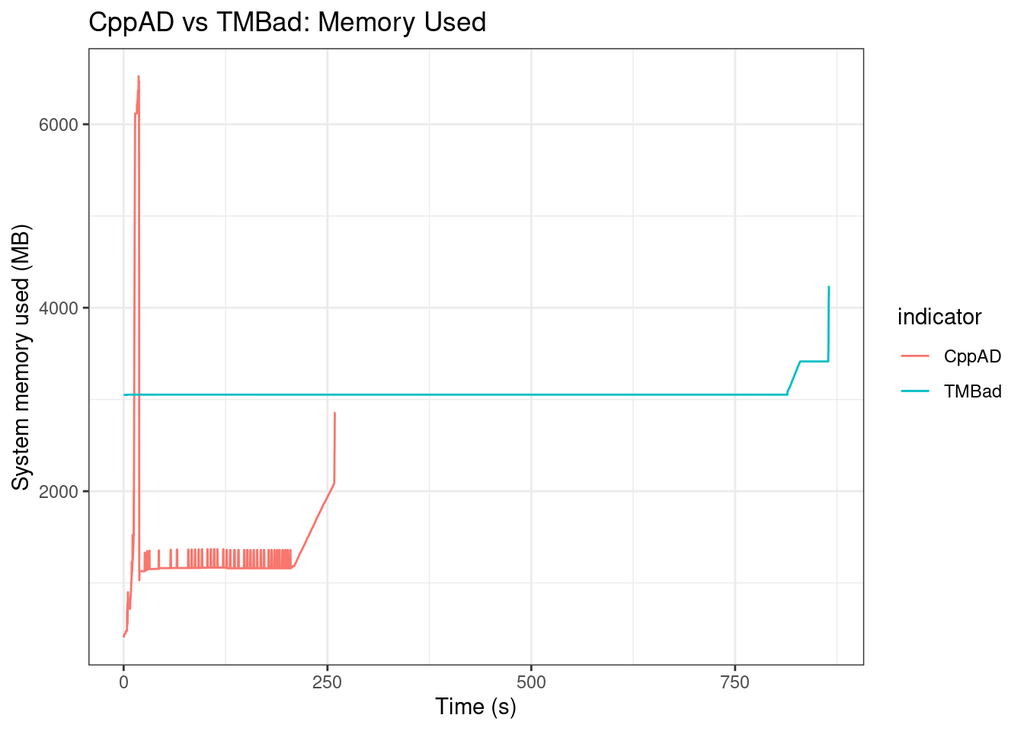

```r
bind_rows(
  select(memprof:::used_memory_total_by_time(fit_cppad$memory_use),
         used = used,
         time),
  select(memprof:::used_memory_total_by_time(fit_tmbad$memory_use),
         used = used,
         time),
  .id = "indicator"
) %>%
  mutate(
    used      = used / 1e6,
    indicator = ifelse(indicator == 1, "CppAD", "TMBad")
  ) %>%
  ggplot(aes(x = time, y = used, colour = indicator)) +
  geom_line() +
  ggtitle("CppAD vs TMBad: Memory Used") +
  xlab("Time (s)") +
  ylab("System memory used (MB)") +
  theme_bw()
```

## 1. Results

We can calculate quantiles from our sample values, and plot these, to compare results from both models:

```r
res_cppad <- fit_cppad$result
res_tmbad <- fit_tmbad$result

out_cppad <- threemc::compute_quantiles(
  shell_dat_lso, fit = res_cppad, area_lev = 1
)
out_tmbad <- threemc::compute_quantiles(
  shell_dat_lso, fit = res_tmbad, area_lev = 1
)
```

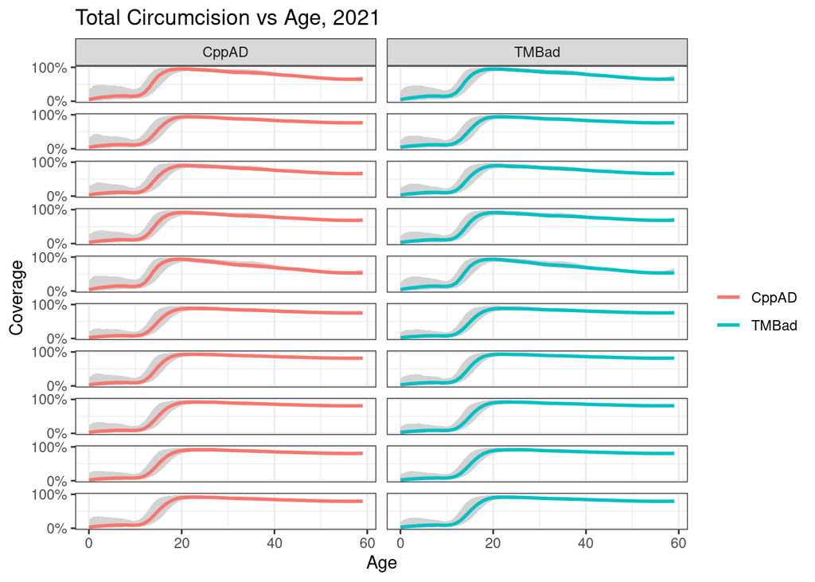

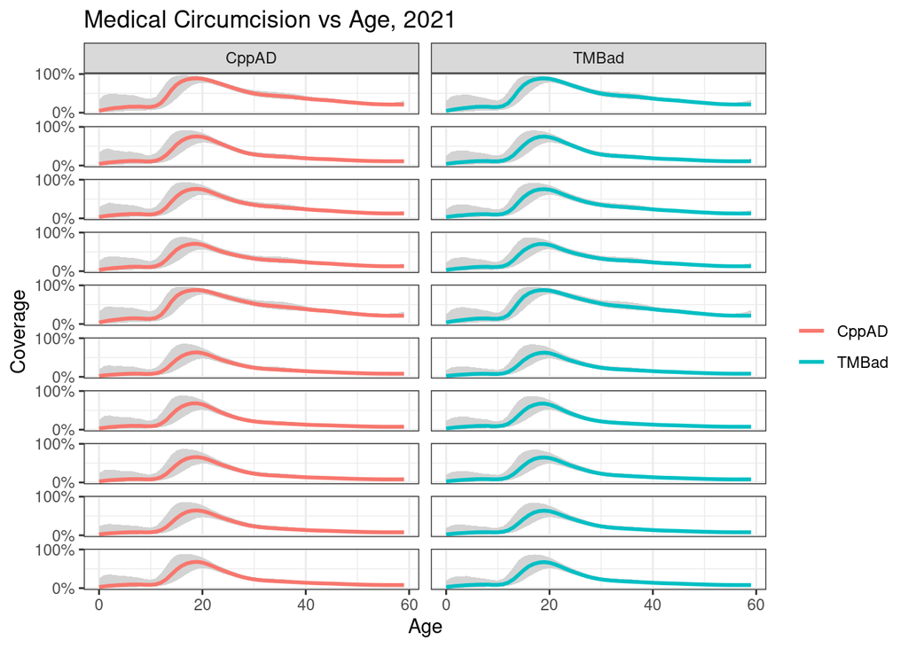

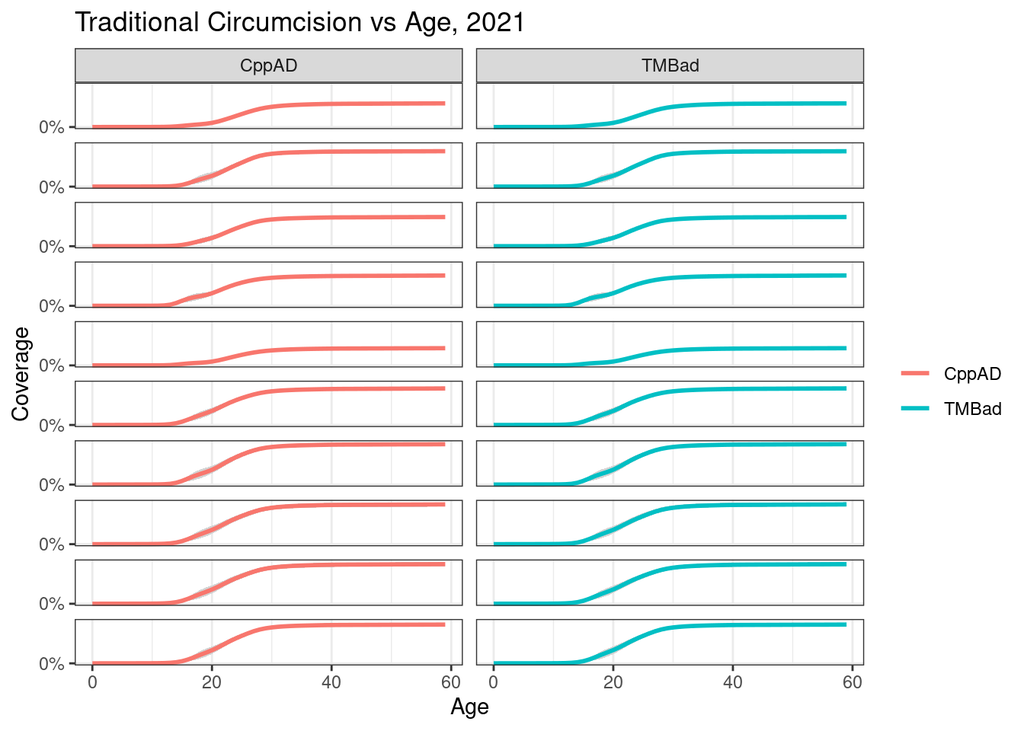

```r
out_joined <- bind_rows(out_cppad, out_tmbad, .id = "indicator") %>%
  filter(year == max(.data$year)) %>%
  mutate(indicator = ifelse(indicator == 1, "CppAD", "TMBad"))

plt_fun <- function(out_joined, y_var) {

 out_joined %>%
  ggplot(aes(
    x      = circ_age,
    # y      = cum_incM,
    y      = .data[[paste0(y_var, "M")]],
    ymin   = .data[[paste0(y_var, "L")]],
    ymax   = .data[[paste0(y_var, "U")]],
    group  = as.factor(indicator),
    colour = as.factor(indicator)
  )) +
  geom_ribbon(
    fill = "lightgrey",
    colour = NA
  ) +
  geom_line(size = 1) +
  scale_y_continuous(breaks = seq(0, 1, by = 1), labels = scales::label_percent(accuracy = 1)) +
  labs(
    x = "Age", y = "Coverage", colour = ""
  ) +
  theme_bw() +
  facet_grid(area_name ~ indicator) +
  theme(

    panel.spacing = unit(6.5, "points"),
    strip.text.y = element_blank(),
    strip.background.y = element_blank()
  )
}

cols <- c("cum_inc", "cum_inc_mmc", "cum_inc_tmc")
titles <- paste(
  c("Total", "Medical", "Traditional"), "Circumcision vs Age, 2021"
)

lapply(seq_along(cols), function(i) {
  plt_fun(out_joined, cols[i]) +
    ggtitle(titles[i])
})
```

We can see that the two frameworks give what are essentially the same results.

## 2. Time

```r
bm_res <- microbenchmark(
  "CppAD" = threemc_fit(
  shell_dat_lso, areas, mod_cppad, silent = TRUE
  ),
  "TMBad" = threemc_fit(
  shell_dat_lso, areas, mod_tmbad, silent = TRUE
  ),
  times = 5
)
```

```r
bm_res
```

```
## Unit: seconds
##   expr      min       lq     mean   median       uq      max neval
##  CppAD 173.2844 192.2325 198.8721 195.6191 201.4885 231.7359     5
##  TMBad 593.5282 601.4778 632.4172 616.7417 625.0198 725.3186     5
```

Therefore, CppAD is, on average, ~3.2 times faster than TMBad.

It is unclear how this scales up for larger countries. To simulate this, model Lesotho at the country level:

```r
shell_dat_partial <- shell_dat_lso %>%
    filter(area_level == 1) %>%
    mutate(across(N:icens, ~ . * population)) %>%
    group_by(year, circ_age, time, age) %>%
    summarise(across(population:icens, sum), .groups = "drop") %>%
    mutate(
        across(N:icens, ~ . / population),
        area_id    = "LSO",
        space      = 1,
        area_level = 0
    ) %>%
  relocate(area_id, space, area_level)
areas_partial <- filter(areas, area_level == 0)

bm_res_small <- microbenchmark(
  "CppAD" = threemc_fit(
  shell_dat_partial, areas, mod_cppad, silent = TRUE
  ),
  "TMBad" = threemc_fit(
  shell_dat_partial, areas, mod_tmbad, silent = TRUE
  ),
  times = 5
)
```

```r
bm_res_small
```

```
## Unit: seconds
##   expr      min       lq     mean   median       uq      max neval
##  CppAD 43.13502 43.30120 44.00385 43.70182 44.24510 45.63611     5
##  TMBad 54.76203 55.08048 55.87732 55.13356 55.19913 59.21141     5
```

Therefore, CppAD is, on average, ~1.3 times faster than TMBad at the country level (i.e. for a much smaller number of parameters), so unfortunately the difference in fit time for the two different AD schemes appears to increase with the need to estimate more parameters. This may cause our model with a time TMC effect to be very slow. It would probably therefore be a good idea to make the choice of framework an option in `threemc`, whereby the user can choose to prioritise computational or time efficiency.